# **Análises iniciais**

## **Projeto Precificação de imóveis**

**Problema de negócio:**

Você, como **cientista de dados** de uma imobiliária, precisa criar um modelo que consiga estimar os preços de diferentes casas para que o time de vendedores e vendedoras possam negociá-las com potenciais clientes.

Para isso, vamos observar as principais características de casas que já foram vendidas de acordo com a base de dados que recebemos, analisar estes dados e construir um modelo de aprendizado de máquina (ML), averiguando sua eficácia.

**Objetivo**

Estimar preços dos imóveis de acordo com diversas características das propriedades, como área e localização. Para este propósito, vamos:

- Identificar quais fatores contribuem para a precificação dos imóveis;
- Averiguar a influência das características no preço do imóvel;
- Diferenciar quando precisamos transformar ou não as variáveis para uma melhor resposta do modelo;
- Verificar a relação entre as variáveis explicativas e a variável resposta;
- Criar um modelo de regressão linear de múltiplas variáveis;
- Fazer previsões para uma ou mais casas.

**Base de dados:**

Vamos utilizar a base `precos_casa.csv` adaptada de uma base bem conhecida no **Kaggle** chamada [House Prices](https://www.kaggle.com/competitions/house-prices-advanced-regression-techniques/data?select=train.csv).

Esses dados serão lidos a partir do repositório compartilhado pelo GitHub.

## **1.2 - Conhecendo os dados**

```python
import pandas as pd
```

```python
dados = pd.read_csv('https://raw.githubusercontent.com/afonsosr2/data-science-regressao-linear/main/dados/precos_casas.csv')
```

```python
dados.head()
```

|  | valor | area_primeiro_andar | existe_segundo_andar | area_quintal | dist_metro | dist_parque |
| --- | --- | --- | --- | --- | --- | --- |
| 0 | 1042500 | 79.52 | 1 | 23.86 | 1.639 | 3.039 |
| 1 | 907500 | 117.24 | 0 | 35.17 | 1.538 | 10.910 |
| 2 | 1117500 | 85.47 | 1 | 25.64 | 1.275 | 11.791 |
| 3 | 700000 | 89.28 | 1 | 21.07 | 1.223 | 10.877 |
| 4 | 1250000 | 106.37 | 1 | 31.91 | 0.868 | 11.247 |

```python
# Verificando a quantidade de dados
dados.shape
```

```
(1460, 6)
```

```python
# Como estão os meus dados? Temos dados nulos? Quais são seus tipos?
dados.info()
```

```
<class 'pandas.core.frame.DataFrame'>
RangeIndex: 1460 entries, 0 to 1459
Data columns (total 6 columns):
 #   Column                Non-Null Count  Dtype
---  ------                --------------  -----
 0   valor                 1460 non-null   int64
 1   area_primeiro_andar   1460 non-null   float64
 2   existe_segundo_andar  1460 non-null   int64
 3   area_quintal          1460 non-null   float64
 4   dist_metro            1460 non-null   float64
 5   dist_parque           1460 non-null   float64
dtypes: float64(4), int64(2)
memory usage: 68.6 KB
```

## **1.3 - Entendendo a relação dos dados**

Para entender a relação dos dados entre o valor de venda dos imóveis do dataset e suas características vamos utilizar a **Correlação**.

Correlação é uma medida estatística que varia numa escala de -1 a 1, indicando a relação e a dependência entre duas variáveis. Existem três tipos principais de correlação:

1. **Correlação Positiva:** quando uma variável aumenta, a outra tende a aumentar.
2. **Correlação Nula:** não há relação linear entre as variáveis.
3. **Correlação Negativa:** quando uma variável aumenta, a outra tende a diminuir.

Essa medida não só define a direção, como também, a intensidade da relação.

```python
# Correlação entre todo os dados
corr = dados.corr().round(3)
corr
```

|  | valor | area_primeiro_andar | existe_segundo_andar | area_quintal | dist_metro | dist_parque |
| --- | --- | --- | --- | --- | --- | --- |
| valor | 1.000 | 0.606 | 0.138 | 0.614 | -0.644 | -0.071 |
| area_primeiro_andar | 0.606 | 1.000 | -0.339 | 0.820 | -0.369 | -0.058 |
| existe_segundo_andar | 0.138 | -0.339 | 1.000 | -0.301 | -0.191 | -0.007 |
| area_quintal | 0.614 | 0.820 | -0.301 | 1.000 | -0.440 | -0.058 |
| dist_metro | -0.644 | -0.369 | -0.191 | -0.440 | 1.000 | 0.089 |
| dist_parque | -0.071 | -0.058 | -0.007 | -0.058 | 0.089 | 1.000 |

```python
# Correlação do preço de venda
corr["valor"].to_frame()
```

|  | valor |
| --- | --- |
| valor | 1.000 |
| area_primeiro_andar | 0.606 |
| existe_segundo_andar | 0.138 |
| area_quintal | 0.614 |
| dist_metro | -0.644 |
| dist_parque | -0.071 |

## **1.4 - Visualizando uma Regressão Linear com uma variável independente**

```python
# Importando as bibliotecas
import seaborn as sns
import matplotlib.pyplot as plt
```

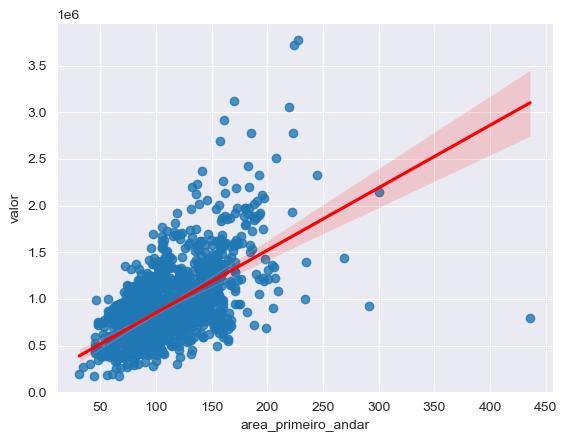

```python
sns.set_style("darkgrid")
sns.regplot(x="area_primeiro_andar", y="valor", data=dados, line_kws={'color':'red'})
plt.show()
```

# **Análises gráficas**

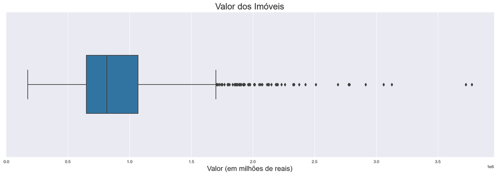

```python
#boxplot para entender a distribuição dos valor por quartil

ax = sns.boxplot(dados, x ="valor", width=0.4)

ax.figure.set_size_inches(20, 6)
ax.set_title('Valor dos Imóveis', fontsize=20)
ax.set_xlabel('Valor (em milhões de reais)', fontsize=16)
plt.show()
```

## **2.2 - Investigando a distribuição de frequências da variável dependente**

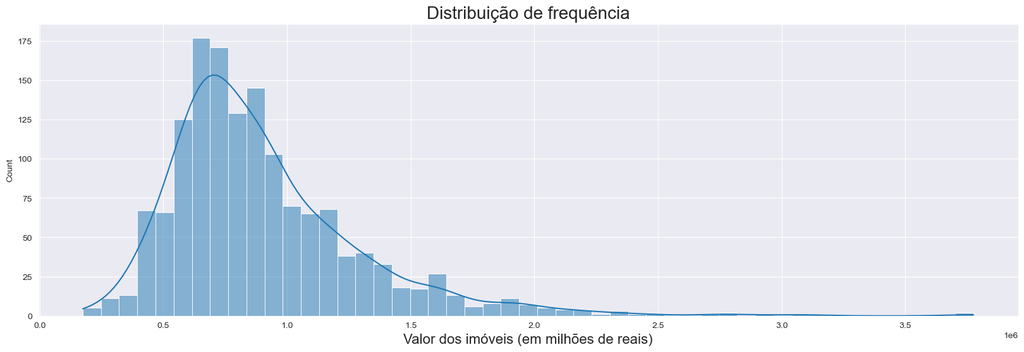

```python
ax = sns.histplot(dados['valor'], kde=True)

ax.figure.set_size_inches(20, 6)
ax.set_title('Distribuição de frequência', fontsize=20)
ax.set_xlabel('Valor dos imóveis (em milhões de reais)', fontsize=16)
plt.show()
```

## **2.3 - Analisando as variáveis independentes**

Vamos agora plotar o relacionamento das variáveis do dataset levando em conta o valor do imóvel utilizando o `pairplot()`

```python
## Colunas dos dados
dados.columns
```

```
Index(['valor', 'area_primeiro_andar', 'existe_segundo_andar', 'area_quintal',
       'dist_metro', 'dist_parque'],
      dtype='object')
```

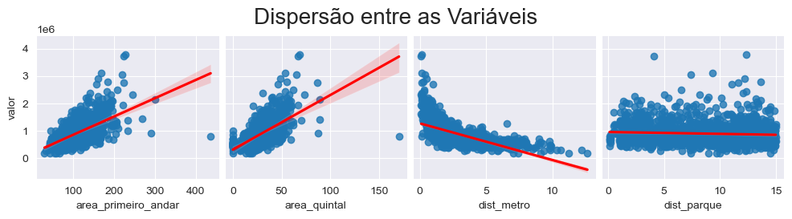

```python
# Pairplot com reta de regressão
ax = sns.pairplot(dados, y_vars="valor", x_vars= ['area_primeiro_andar','area_quintal', 'dist_metro', 'dist_parque'],
                  kind='reg', plot_kws={'line_kws':{'color':'red'}})
ax.figure.suptitle('Dispersão entre as Variáveis', fontsize=20, y=1.05)
plt.show()
```

Já vimos coisas interessantes aqui! Algumas variaveis não tem comportamento linear com variavel dependente.. vamos tentar ajustar isso

# **Transformação de variáveis**

```python
import numpy as np
```

### **Aplicando a transformação logarítmica**

- [np.log()](https://numpy.org/doc/stable/reference/generated/numpy.log.html)
- [np.log1p()](https://numpy.org/doc/stable/reference/generated/numpy.log1p.html)

```python
# Verificando se há 0 nas variáveis explicativas do nosso df
dados.describe().round(2)
```

|  | valor | area_primeiro_andar | existe_segundo_andar | area_quintal | dist_metro | dist_parque |
| --- | --- | --- | --- | --- | --- | --- |
| count | 1460.00 | 1460.00 | 1460.00 | 1460.00 | 1460.00 | 1460.00 |
| mean | 904605.98 | 108.01 | 0.43 | 29.47 | 2.77 | 8.15 |
| std | 397212.51 | 35.92 | 0.50 | 12.23 | 1.91 | 4.20 |
| min | 174500.00 | 31.03 | 0.00 | 0.00 | 0.10 | 0.12 |
| 25% | 649875.00 | 81.94 | 0.00 | 22.18 | 1.42 | 4.44 |
| 50% | 815000.00 | 100.98 | 0.00 | 27.64 | 2.26 | 8.72 |
| 75% | 1070000.00 | 129.25 | 1.00 | 36.18 | 3.89 | 11.63 |
| max | 3775000.00 | 435.90 | 1.00 | 170.29 | 12.65 | 15.00 |

```python
# Transformando as variáveis explicativas e resposta utilizando o logaritmo
# variavel log_area_quintal precisa ser log1p
dados['log_valor'] = np.log(dados['valor'])
dados['log_area_primeiro_andar'] = np.log(dados['area_primeiro_andar'])
dados['log_area_quintal'] = np.log1p(dados['area_quintal'])
dados['log_dist_metro'] = np.log(dados['dist_metro'])
dados['log_dist_parque'] = np.log(dados['dist_parque'])
```

```python
# Lendo os dados
dados.head(3)
```

|  | valor | area_primeiro_andar | existe_segundo_andar | area_quintal | dist_metro | dist_parque | log_valor | log_area_primeiro_andar | log_area_quintal | log_dist_metro | log_dist_parque |
| --- | --- | --- | --- | --- | --- | --- | --- | --- | --- | --- | --- |
| 0 | 1042500 | 79.52 | 1 | 23.86 | 1.639 | 3.039 | 13.857132 | 4.376009 | 3.213260 | 0.494086 | 1.111529 |
| 1 | 907500 | 117.24 | 0 | 35.17 | 1.538 | 10.910 | 13.718449 | 4.764223 | 3.588230 | 0.430483 | 2.389680 |
| 2 | 1117500 | 85.47 | 1 | 25.64 | 1.275 | 11.791 | 13.926605 | 4.448165 | 3.282414 | 0.242946 | 2.467337 |

Agora verificando como ficaram as nossas variáveis graficamente?

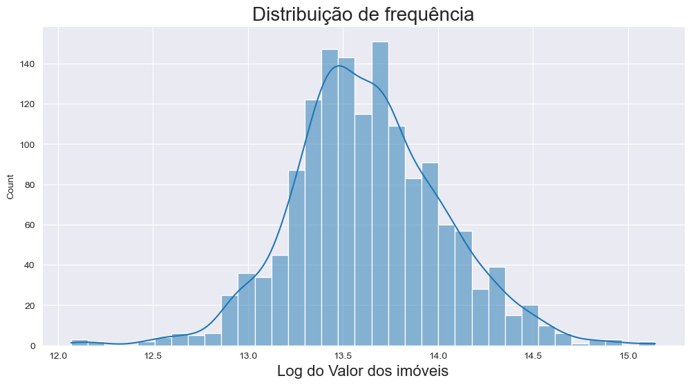

```python
ax = sns.histplot(dados['log_valor'], kde=True)

ax.figure.set_size_inches(12, 6)
ax.set_title('Distribuição de frequência', fontsize=20)
ax.set_xlabel('Log do Valor dos imóveis', fontsize=16)
plt.show()
```

Vamos agora analisar como ficaram também as distribuições de nossas variáveis explicativas separadamente de acordo com o valor do imóvel?

## **3.2 - Verificando a relação linear**

Vamos utilizar basicamente o mesmo código, só lembrando de colocar o `log_` em todas que sofreram uma transformação logarítmica

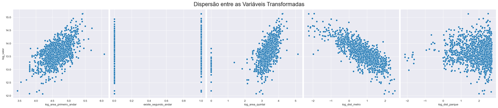

```python
ax = sns.pairplot(dados, y_vars="log_valor", x_vars= ['log_area_primeiro_andar', 'existe_segundo_andar', 'log_area_quintal', 'log_dist_metro','log_dist_parque'], height= 5)
ax.figure.suptitle('Dispersão entre as Variáveis Transformadas', fontsize=20, y=1.05)
plt.show()
```

# **Regressão linear múltipla**

## **4.1 - Preparando os dados**

O primeiro passo para criação do nosso modelo de Regressão Linear é a separação dos dados entre datasets de treino e teste.

```python
# Importando o método de separação dos dados de treino e teste
from sklearn.model_selection import train_test_split
```

```python
# Definindo X e y
y = dados['log_valor']
X = dados[['log_area_primeiro_andar', 'existe_segundo_andar', 'log_area_quintal', 'log_dist_metro', 'log_dist_parque']]
```

```python
# Dividindo os dados
X_train, X_test, y_train, y_test = train_test_split(X, y, test_size=0.3, random_state=1991)
```

```python
X_train
```

|  | log_area_primeiro_andar | existe_segundo_andar | log_area_quintal | log_dist_metro | log_dist_parque |
| --- | --- | --- | --- | --- | --- |
| 480 | 5.146738 | 0 | 3.952973 | -1.158362 | 1.092930 |
| 175 | 5.300714 | 0 | 3.540959 | 0.579978 | 2.571467 |
| 891 | 4.445940 | 1 | 3.280535 | 0.758935 | 2.424537 |
| 101 | 4.508329 | 1 | 3.075005 | 0.948177 | 0.506215 |
| 403 | 4.684259 | 1 | 3.490429 | -0.050241 | 1.863770 |
| ... | ... | ... | ... | ... | ... |
| 519 | 4.775250 | 1 | 3.598955 | 0.431133 | 2.296768 |
| 397 | 4.399130 | 1 | 3.222071 | 1.425515 | 0.215111 |
| 1331 | 4.484470 | 0 | 3.272985 | 1.203273 | 1.000632 |
| 1102 | 4.657288 | 0 | 3.372455 | 1.310223 | 1.360977 |
| 1344 | 4.214052 | 1 | 3.058237 | 0.607044 | 2.625031 |

1022 rows × 5 columns

```python
X_test.shape
```

```
(438, 5)
```

## **4.2 - Avaliando as estatísticas do modelo com Statsmodels**

Agora vamos estimar nosso modelo inicialmente com Statsmodels verificando as estatísticas do modelo para o caso de todas as variáveis adicionadas.

```python
import statsmodels.api as sm
```

```python
X_train_com_constante = sm.add_constant(X_train)
```

```python
X_train_com_constante.head()
```

|  | const | log_area_primeiro_andar | existe_segundo_andar | log_area_quintal | log_dist_metro | log_dist_parque |
| --- | --- | --- | --- | --- | --- | --- |
| 480 | 1.0 | 5.146738 | 0 | 3.952973 | -1.158362 | 1.092930 |
| 175 | 1.0 | 5.300714 | 0 | 3.540959 | 0.579978 | 2.571467 |
| 891 | 1.0 | 4.445940 | 1 | 3.280535 | 0.758935 | 2.424537 |
| 101 | 1.0 | 4.508329 | 1 | 3.075005 | 0.948177 | 0.506215 |
| 403 | 1.0 | 4.684259 | 1 | 3.490429 | -0.050241 | 1.863770 |

```python
modelo_statsmodels = sm.OLS(y_train, X_train_com_constante, hasconst=True).fit()
print(modelo_statsmodels.summary())
```

```
                            OLS Regression Results
==============================================================================
Dep. Variable:              log_valor   R-squared:                       0.759
Model:                            OLS   Adj. R-squared:                  0.758
Method:                 Least Squares   F-statistic:                     641.1
Date:                Tue, 26 May 2026   Prob (F-statistic):          3.38e-311
Time:                        21:52:51   Log-Likelihood:                 214.53
No. Observations:                1022   AIC:                            -417.1
Df Residuals:                    1016   BIC:                            -387.5
Df Model:                           5
Covariance Type:            nonrobust
===========================================================================================
                              coef    std err          t      P>|t|      [0.025      0.975]
-------------------------------------------------------------------------------------------
const                      11.1983      0.127     88.044      0.000      10.949      11.448
log_area_primeiro_andar     0.4983      0.026     18.955      0.000       0.447       0.550
existe_segundo_andar        0.1871      0.015     12.827      0.000       0.158       0.216
log_area_quintal            0.0793      0.011      7.134      0.000       0.057       0.101
log_dist_metro             -0.2607      0.010    -26.284      0.000      -0.280      -0.241
log_dist_parque            -0.0092      0.008     -1.149      0.251      -0.025       0.006
==============================================================================
Omnibus:                      424.287   Durbin-Watson:                   2.046
Prob(Omnibus):                  0.000   Jarque-Bera (JB):             3729.961
Skew:                          -1.668   Prob(JB):                         0.00
Kurtosis:                      11.744   Cond. No.                         130.
==============================================================================

Notes:
[1] Standard Errors assume that the covariance matrix of the errors is correctly specified.
```

## **4.3 - Treinando o modelo**

```python
from sklearn.linear_model import LinearRegression
from sklearn import metrics
```

```python
# Atualizando as variáveis de entrada do modelo
X_train_novo = X_train.drop('log_dist_parque', axis=1)
X_test_novo = X_test.drop('log_dist_parque', axis=1)
```

```python
# Verificando o X_train_novo
X_train_novo.head()
```

|  | log_area_primeiro_andar | existe_segundo_andar | log_area_quintal | log_dist_metro |
| --- | --- | --- | --- | --- |
| 480 | 5.146738 | 0 | 3.952973 | -1.158362 |
| 175 | 5.300714 | 0 | 3.540959 | 0.579978 |
| 891 | 4.445940 | 1 | 3.280535 | 0.758935 |
| 101 | 4.508329 | 1 | 3.075005 | 0.948177 |
| 403 | 4.684259 | 1 | 3.490429 | -0.050241 |

```python
# Instanciando o modelo
modelo = LinearRegression()
```

```python
# Treinando o modelo com os dados de treino
modelo.fit(X_train_novo, y_train)
```

```
LinearRegression()
```

### **Obtendo o coeficiente de determinação (R²) do modelo estimado com os dados de treino**

O coeficiente de determinação (R²) é uma medida resumida, variando de 0 a 1, que diz quanto a linha de regressão ajusta-se aos dados.

Por exemplo, um R² = 0.8 representa que 80% da variação da variável dependente é explicada pelas variáveis independentes escolhidas no modelo.

#### **R² dos dados de treino**

```python
print(f"R² = {modelo.score(X_train_novo, y_train).round(3)}")
```

```
R² = 0.759
```

#### **Gerando previsões para os dados de teste do modelo**

```python
y_previsto = modelo.predict(X_test_novo)
```

#### **R² dos dados de previsão**

```python
print(f"R² = {metrics.r2_score(y_test, y_previsto).round(3)}")
```

```
R² = 0.738
```

## **4.4 - Precificando uma casa**

# com o modelo treinado, vamos estimar o valor da casa abaixo

[figure not shown]

```python
# Quais são as features do nosso modelo?
modelo.feature_names_in_
```

```
array(['log_area_primeiro_andar', 'existe_segundo_andar',
       'log_area_quintal', 'log_dist_metro'], dtype=object)
```

```python
# Nova casa.. com dados da figura
nova_casa = pd.DataFrame({
    'log_area_primeiro_andar': [np.log(150)],
    'existe_segundo_andar': [1],
    'log_area_quintal': [np.log1p(80)],
    'log_dist_metro': [np.log(2)]
})
```

```python
# Qual o preço dessa casa? .. em escala logaritimica
modelo.predict(nova_casa)[0]
```

```
14.03348183137059
```

```python
print(f'R$ {np.exp(modelo.predict(nova_casa)[0]):,.2f}')
```

```
R$ 1,243,551.34
```

Prontinho, conseguimos finalmente precificar a nossa 1ª casa com modelo que criamos.

# **Entendendo os resultados**

## **5.1 - Obtendo os coeficientes da regressão linear**

#### **Intercepto**

O **intercepto** representa o valor médio em $Y$ (Valor do imóvel) tendo todas as variáveis explicativas excluídas do modelo.

```python
## lendo o valor do intercepto em log
modelo.intercept_
```

```
11.174572203750294
```

```python
## Transformando o efeito do intercepto em reais
np.exp(modelo.intercept_)
```

```
71294.33881566528
```

```python
# Lendo os coeficientes
modelo.coef_
```

```
array([ 0.49955726,  0.1877953 ,  0.07936964, -0.26079708])
```

### **Construindo uma tabela (DataFrame) com os coeficientes e seus valores**

```python
X_train_novo.columns
```

```
Index(['log_area_primeiro_andar', 'existe_segundo_andar', 'log_area_quintal',
       'log_dist_metro'],
      dtype='object')
```

```python
## Criando o índice dos coeficientes
index = ['Intercepto', 'log_area_primeiro_andar', 'existe_segundo_andar', 'log_area_quintal',
       'log_dist_metro']
```

```python
## Criando o df
df_params = pd.DataFrame(data = np.append(modelo.intercept_, modelo.coef_), index=index, columns=['Parâmetros'])
```

```python
df_params.round(3)
```

|  | Parâmetros |
| --- | --- |
| Intercepto | 11.175 |
| log_area_primeiro_andar | 0.500 |
| existe_segundo_andar | 0.188 |
| log_area_quintal | 0.079 |
| log_dist_metro | -0.261 |

## **5.2 Interpretando os coeficientes estimados**

#### **Nosso Modelo:**

[figure not shown]

**Intercepto →** Excluindo o efeito de todas as variáveis explicativas, o efeito médio no Valor do Imóvel seria de **R$ 71.294,33**. (exp[11.175])

**Área do 1º andar (m²)** → Mantendo-se os valores de todas as outras variáveis explicativas constantes, um acréscimo de 1% na Área do 1º andar do imóvel gera, em média, um **acréscimo de 0.5%** no Valor do Imóvel.

**Área do Quintal (m²)** → Mantendo-se os valores de todas as outras variáveis explicativas constantes, um acréscimo de 1% na Área do Quintal do imóvel gera, em média, um **acréscimo de 0.079%** no Valor do Imóvel.

**Distância até o metrô (km)** → Mantendo-se os valores de todas as outras variáveis explicativas constantes, um acréscimo de 1% na Distância até o metrô gera, em média, um **decréscimo de 0.26%** no Valor do Imóvel.

## **5.3 - Analisando graficamente os resultados do modelo**

Vamos agora analisar graficamente os resultados de nosso modelo, gerando previsões de casas para os dados de treino.

### **Analisando pelos dados de TREINO**

#### **Gerando previsões para os dados de treino**

```python
y_previsto_train = modelo.predict(X_train_novo)
```

#### **Gráfico de dispersão entre o valor estimado e real**

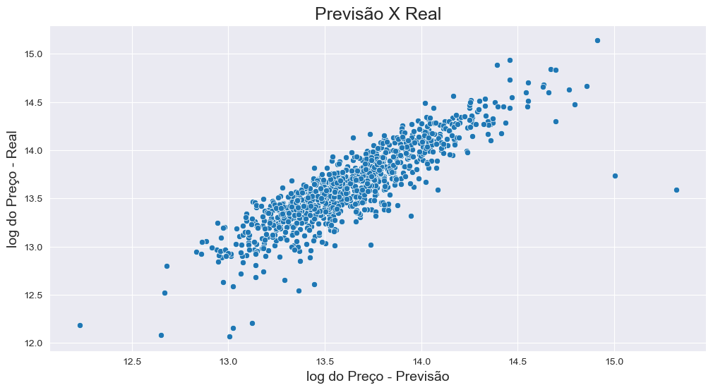

```python
ax = sns.scatterplot(x= y_previsto_train, y= y_train)

ax.figure.set_size_inches(12, 6)
ax.set_title('Previsão X Real', fontsize=18)
ax.set_xlabel('log do Preço - Previsão', fontsize=14)
ax.set_ylabel('log do Preço - Real', fontsize=14)
plt.show()
```

#### **Obtendo os resíduos e observando seu comportamento**

```python
residuo = y_train - y_previsto_train
```

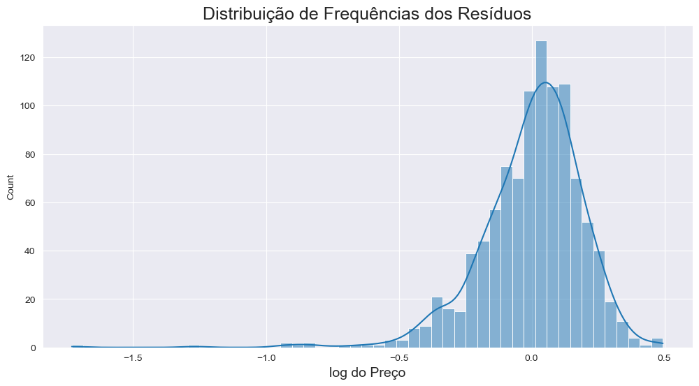

```python
ax = sns.histplot(residuo, kde=True)

ax.figure.set_size_inches(12, 6)
ax.set_title('Distribuição de Frequências dos Resíduos', fontsize=18)
ax.set_xlabel('log do Preço', fontsize=14)
plt.show()
```

##### **Homocedasticidade do modelo**

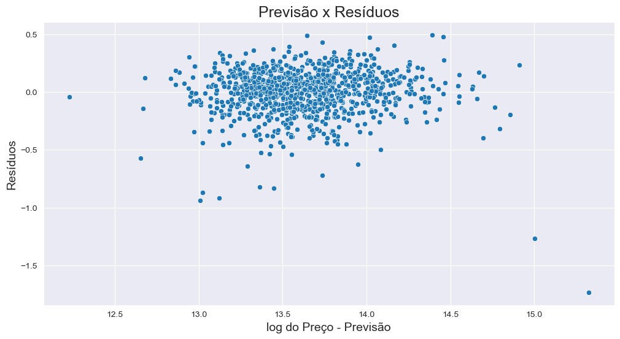

```python
ax = sns.scatterplot(x= y_previsto_train, y=residuo)

ax.figure.set_size_inches(12, 6)
ax.set_title('Previsão x Resíduos', fontsize=18)
ax.set_xlabel('log do Preço - Previsão', fontsize=14)
ax.set_ylabel('Resíduos', fontsize=14)
plt.show()
```

## **5.4 - conclusão sobre o modelo**

O modelo de regressão apresentou desempenho satisfatório, alcançando um coeficiente de determinação (R²) de 0,738, indicando que aproximadamente 73,8% da variabilidade dos preços das casas foi explicada pelas variáveis utilizadas.

A análise dos resíduos demonstrou uma distribuição aproximadamente normal e concentrada em torno de zero, sugerindo que o modelo possui boa capacidade de ajuste. Entretanto, observam-se alguns outliers e uma leve assimetria na distribuição, indicando a existência de erros mais elevados em determinadas observações.

De forma geral, o modelo apresentou resultados consistentes e adequados para previsão de preços, embora ainda exista espaço para melhorias por meio de engenharia de atributos, tratamento de outliers e testes com modelos mais robustos.

# Por: Fernando Humberto :-)